# Kaggle survey

Jerald Melukkaran

2025-03-22

#### Introduction

The data set we are going to analyse in this part of the project is a Kaggle Data science and Machine learning survey that has around 20,000 responses from 171 different countries . The questions for the survey mainly revolved around the different data science and machine learning technologies and skills that were being commonly used among a large variety of people with different educational and work related backgrounds.

We intend to use this data to analyse first how data skill proportion across different categories compare between students and non students. And further how it compares to our previous data sets that involve job posting skills

#### Data tidying and cleanup

This a great source of information albeit having a weirdly structured data set. Each multiple choice question in this survey is split into a certain number of columns depending on how many choices there are. For eg Question 7 , a question about the programming languages being used has 13 options , and each of these options get their own column named Q7_PART_1 to Q7_Part_12 and then one for the option “Other” named Q7_Other.

The first task is to separate out only the Question columns relevant to Data science skill, Education and Work. We also drop fields where the Work column specifies not employed.

```
## # A tibble: 6 × 230
##   Education    Work  Q7_Part_1 Q7_Part_2 Q7_Part_3 Q7_Part_4 Q7_Part_5 Q7_Part_6
##   <chr>        <chr> <chr>     <chr>     <chr>     <chr>     <chr>     <chr>
## 1 Doctoral de… Stud… Python    R         SQL       C         <NA>      <NA>
## 2 Master’s de… Data… Python    R         SQL       <NA>      <NA>      <NA>
## 3 Bachelor’s … Soft… <NA>      <NA>      <NA>      <NA>      <NA>      Java
## 4 Master’s de… Data… Python    <NA>      SQL       <NA>      <NA>      <NA>
## 5 Master’s de… Soft… Python    <NA>      <NA>      <NA>      <NA>      <NA>
## 6 Bachelor’s … Data… Python    R         <NA>      <NA>      <NA>      <NA>
## # ℹ 222 more variables: Q7_Part_7 <chr>, Q7_Part_8 <chr>, Q7_Part_9 <chr>,
## #   Q7_Part_10 <chr>, Q7_Part_11 <chr>, Q7_Part_12 <chr>, Q7_OTHER <chr>,
## #   Q9_Part_1 <chr>, Q9_Part_2 <chr>, Q9_Part_3 <chr>, Q9_Part_4 <chr>,
## #   Q9_Part_5 <chr>, Q9_Part_6 <chr>, Q9_Part_7 <chr>, Q9_Part_8 <chr>,
## #   Q9_Part_9 <chr>, Q9_Part_10 <chr>, Q9_Part_11 <chr>, Q9_OTHER <chr>,
## #   Q10_Part_1 <chr>, Q10_Part_2 <chr>, Q10_Part_3 <chr>, Q10_Part_4 <chr>,
## #   Q10_Part_5 <chr>, Q10_Part_6 <chr>, Q10_Part_7 <chr>, Q10_Part_8 <chr>, …
```

Our next task is to combine the Question columns so that every multiple choice answer for a particular question can be represented in just one column with the answers separated by commas. We can then name this column with the particular skill category that is being addressed with this question

```
## # A tibble: 83 × 15
##    Work                  Education     `Notebook products` `Visualisation tools`
##    <chr>                 <chr>         <chr>               <chr>
##  1 Business Analyst      Bachelor’s d… IBM Watson Studio,… Matplotlib, Seaborn,…
##  2 Business Analyst      Doctoral deg… Kaggle Notebooks, … Matplotlib, Geoplotl…
##  3 Business Analyst      I prefer not… Kaggle Notebooks, … Matplotlib, Seaborn,…
##  4 Business Analyst      Master’s deg… Kaggle Notebooks, … Ggplot / ggplot2, Sh…
##  5 Business Analyst      No formal ed… Kaggle Notebooks, … Plotly / Plotly Expr…
##  6 Business Analyst      Professional… Kaggle Notebooks, … Matplotlib, Seaborn,…
##  7 Business Analyst      Some college… Kaggle Notebooks, … Bokeh, Matplotlib, S…
##  8 DBA/Database Engineer Bachelor’s d… Colab Notebooks, K… Matplotlib, Ggplot /…
##  9 DBA/Database Engineer Doctoral deg… Azure Notebooks, B… Seaborn, Plotly / Pl…
## 10 DBA/Database Engineer I prefer not… Kaggle Notebooks, … Ggplot / ggplot2, Bo…
## # ℹ 73 more rows
## # ℹ 11 more variables: `Learning frameworks` <chr>, `ML algorithms` <chr>,
## #   `Computer vision` <chr>, `NLP methods` <chr>, `Cloud computing` <chr>,
## #   `Machine learning` <chr>, `Big data products` <chr>, `BI tools` <chr>,
## #   `AML tools` <chr>, `Programming language` <chr>, IDE <chr>
```

Now that we have the skills all distributed in their right category, we can calculate their frequency to understand how certain skills categories are more commonly expressed.

```
## # A tibble: 83 × 15
##    Work                  Education     `Notebook products` `Visualisation tools`
##    <chr>                 <chr>                       <int>                 <int>
##  1 Business Analyst      Bachelor’s d…                 219                   340
##  2 Business Analyst      Doctoral deg…                  28                    56
##  3 Business Analyst      I prefer not…                   7                    13
##  4 Business Analyst      Master’s deg…                 361                   686
##  5 Business Analyst      No formal ed…                   7                    16
##  6 Business Analyst      Professional…                  40                    57
##  7 Business Analyst      Some college…                  20                    31
##  8 DBA/Database Engineer Bachelor’s d…                  23                    58
##  9 DBA/Database Engineer Doctoral deg…                   9                    12
## 10 DBA/Database Engineer I prefer not…                   5                     7
## # ℹ 73 more rows
## # ℹ 11 more variables: `Learning frameworks` <int>, `ML algorithms` <int>,
## #   `Computer vision` <int>, `NLP methods` <int>, `Cloud computing` <int>,
## #   `Machine learning` <int>, `Big data products` <int>, `BI tools` <int>,
## #   `AML tools` <int>, `Programming language` <int>, IDE <int>
```

We can also now start separating the Students from the non students and plot a bar chart to see how the different skill categories compare in frequency.

```
## # A tibble: 26 × 3
##    `Skill name`        `Skill count` Work
##    <chr>                       <int> <chr>
##  1 Notebook products            5307 Student
##  2 Visualisation tools          7724 Student
##  3 Learning frameworks          8145 Student
##  4 ML algorithms               12586 Student
##  5 Computer vision             11627 Student
##  6 NLP methods                  2897 Student
##  7 Cloud computing              8492 Student
##  8 Machine learning             8699 Student
##  9 Big data products           11040 Student
## 10 BI tools                     5628 Student
## # ℹ 16 more rows
```

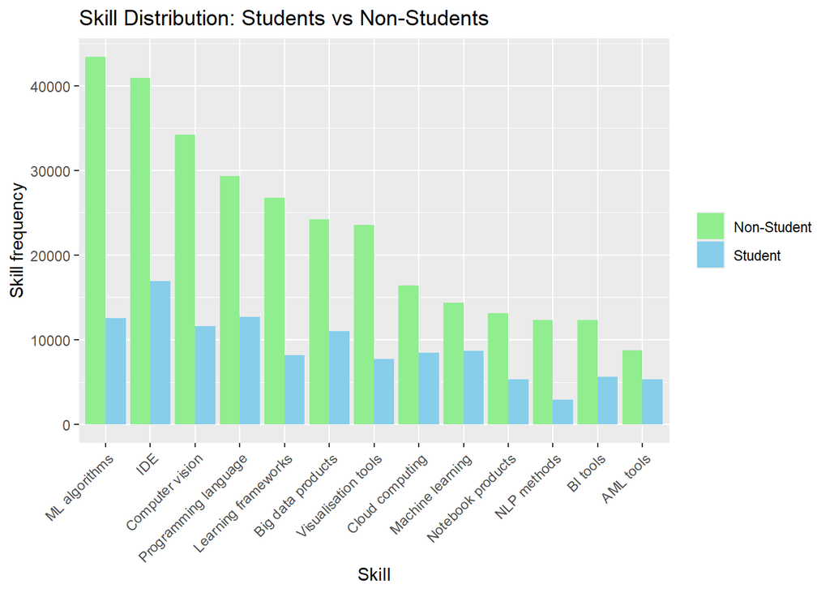

While we can notice a trend in the distribution of different data science skill categories, we also notice a major disparity between the students and non students. Initially we assumed that this might just be because people at work might tend to have skill set that is much wider reaching than a students, we immediately noticed the other issue , the disparity in numbers between students and non students.

In this data set we have a lot more non-students than students. So its essential that we normalize the data to get a better representation of the skill set distribution

This also lets us compare how the skills are distributed within the groups of students and non students to see what each group is more focused

```r
total_skill_count_student <- student_data %>%
  select(-Education, -Work) %>%
  summarise(across(everything(), sum, na.rm = TRUE)) %>%
  sum()
```

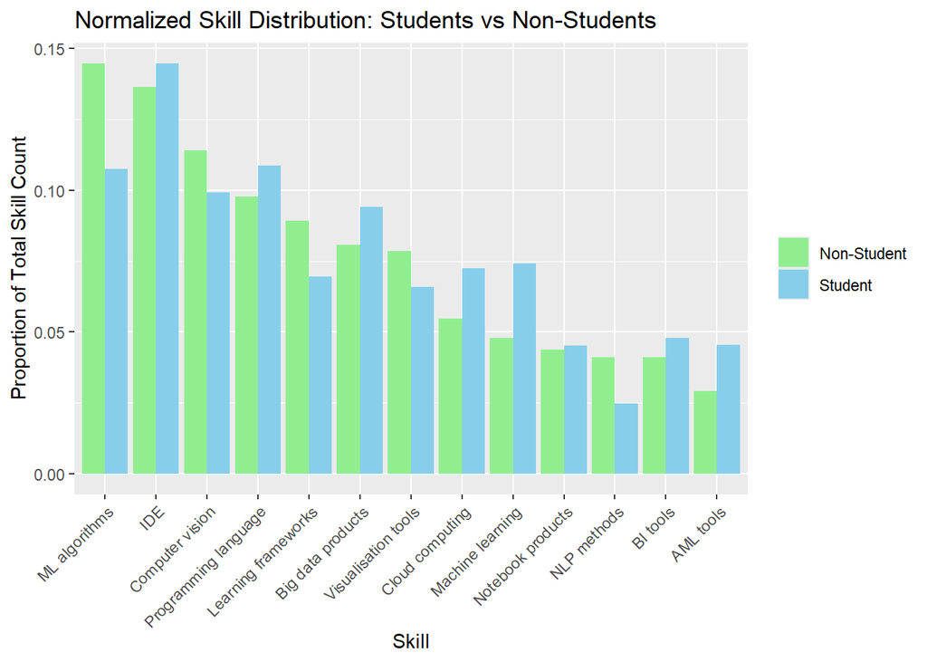

```r
total_skill_count_non_student <- non_student_data %>%
  select(-Education, -Work) %>%
  summarise(across(everything(), sum, na.rm = TRUE)) %>%
  sum()

normalized_skill_summary <- combined_skill_summary %>%
  mutate(`Normalized Skill count` = case_when(
    Work == "Student" ~ `Skill count` / total_skill_count_student,
    Work == "Non-Student" ~ `Skill count` / total_skill_count_non_student
  ))

normalized_skill_summary <- normalized_skill_summary %>%
  mutate(`Skill name` = factor(`Skill name`,
                               levels = normalized_skill_summary %>%
                                 filter(Work == "Non-Student") %>%
                                 arrange(desc(`Normalized Skill count`)) %>%
                                 pull(`Skill name`)))

ggplot(normalized_skill_summary, aes(x = `Skill name`, y = `Normalized Skill count`, fill = Work)) +
  geom_bar(stat = "identity", position = "dodge") +
  labs(title = "Normalized Skill Distribution: Students vs Non-Students",
       x = "Skill",
       y = "Proportion of Total Skill Count") +
  theme(axis.text.x = element_text(angle = 45, hjust = 1),
        legend.title = element_blank()) +
  scale_fill_manual(values = c("Student" = "skyblue", "Non-Student" = "lightgreen"))
```

### Results

This is good representation of what the focus is when comparing skill groups between students and non students. For those with active data skill jobs, the skills seems to be more skewed towards Machine learning algorithms, learning frameworks, visualization tools, computer vision and Natural Language Processing Methodologies. These are often advanced level skills that come with years of experience and it makes sense that this data indicates the same.

And for students the skill categories for which their proportions are higher in includes Programming languages , Integrated development Environments, AML tools and Cloud computing. Students when they start off are often more exposed to different languages , IDE’s and tools and are not usually specialized in one particular framework. This is the stage where they are the most flexible and will usually have a wider scope while they decide one which field to go into next Once they get into a profession, their choices usually narrow down to the industry standards that have been put into place affect the proportion of skills that they have while their focus becomes a lot more narrower.

We also get a general spread of how skills are distributed across both groups with the highest proportion for both groups falling in the skill groups of machine learning algorithms, IDE , Computer vision (this includes general purpose image and video tools, segmentation methods, detection methods, classification and other generative networks ) and programming languages.

Click here to go back to the main page

- [Main Page](https://htmlpreview.github.io/?https://github.com/jerryjerald27/DATA607_Project3/blob/main/FInal_Project_Deliverable.html)